# Try Proteomics Task

## Assignment details

**Input**:

1. protein abundance measured by label-free mass-spectrometry for chronic lymphocytic leukemia (CLL) patient samples
2. basic annotations for those samples.

**To do**:

1. to process the protein abundance dataset and assess its quality
2. to identify protein markers for prognosis
3. write a report, preferably to present your analysis results to your potential future dry-lab or wet-lab collaborators

**Specific tasks:**

1. **Data processing**: The protein abundance in the tsv file is not normalized and has missing values, which is very common in the data table you will get from a proteomic facility. You need to use a proper way to normalize the protein abundance and deal with missing values.
2. **Quality assessment**: The protein abundance measurement can often be influenced by technical factors, such as batch effect, operators, total protein concentrations, and free thaw cycles of the cells. Those technical factors could potentially act as confounders for downstream analysis. In the sample annotation table, you will find the technical factors and you need to evaluate whether they will confound downstream analysis.
3. **Identify protein markers for prognosis**: in the sample annotation file, you will find three columns that contain the clinical information, which can be used to estimate the overall survival, of the CLL patients. You need to select proteins whose expression can be used to predict the overall survival of those patients using a proper statistical model. You may also do an enrichment analysis to see which pathway is potentially related to clinical outcome.

## Loading required packages

The installation of these packages can take quite a bit of time. For simplicity of the report, I am not including installation codes of each of these packages. Ideally, I can make a container that has all these packages and use that container on HPC / cloud etc. to maintain reproducibility.

```r
library("xlsx")
library("preprocessCore")
library("msImpute")
library("survival")
library("survminer")
library("ggfortify")
library("RegParallel")
library("stringr")
library("org.Hs.eg.db")
library("ReactomePA")
library("pathfindR")
library("knitr")
```

## Loading the input data

The protein abundance files and metadata were loaded into R environment.

```r
setwd("C:/Documents/personal/task_proteomics/")
list.files("Bioinformatic_task/")
```

```
## [1] "Protein_abundance.tsv" "sampleAnnotation.xls"  "task_description.docx"
```

```r
#load the input data
prot_abun=read.csv("Protein_abundance.tsv",
                   sep="\t",
                   stringsAsFactors = F,
                   check.names = F,
                   row.names = 1)

metadata=read.xlsx(file = "sampleAnnotation.xls",
                   sheetIndex = 1)
```

### Basic checks and queries on input data

```r
print(paste0("Percentage missing=",round(100*(sum(is.na(prot_abun))/(nrow(prot_abun)*ncol(prot_abun))),2), " %"))
```

```
## [1] "Percentage missing=17.06 %"
```

```r
#dimentions
dim(prot_abun)
```

```
## [1] 3942   49
```

```r
dim(metadata)
```

```
## [1] 50  8
```

```r
print("Metadtaa has 1 sample extra")
```

```
## [1] "Metadtaa has 1 sample extra"
```

```r
missing_sample=metadata$sample.ID[!metadata$sample.ID %in% colnames(prot_abun)]

#check the metadata of missing sample
metadata[metadata$sample.ID==missing_sample,]
```

```
##    sample.ID operator batch total.protein.concentration freeThawCycle
## 50    A_1_50       NA    NA                          NA            NA
##    date.of.diagnosis  died last.known.alive
## 50        2016-05-03 FALSE       2017-08-21
```

```r
print("most of metadata from missing sample is not available")
```

```
## [1] "most of metadata from missing sample is not available"
```

```r
#create a new metadata removing the sample without protein data

metadata_filter=metadata[metadata$sample.ID %in% colnames(prot_abun),]
row.names(metadata_filter)=metadata_filter$sample.ID
metadata_filter$sample.ID=NULL

#order the protein abundance columns to match the order of metadata
prot_abun_order=prot_abun[,row.names(metadata_filter)]
```

## Data Processing

```r
#quantile normalization
qn_pa=normalize.quantiles(as.matrix(prot_abun_order))

row.names(qn_pa)=row.names(prot_abun_order)
colnames(qn_pa)=colnames(prot_abun_order)

#log scaling
log_qn_pa=log2(qn_pa)

#checking for proteins which are missing for most of the samples
max(rowSums( is.na(log_qn_pa)))
```

```
## [1] 48
```

```r
table(rowSums( is.na(log_qn_pa)))
```

```
##
##    0    1    2    3    4    5    6    7    8    9   10   11   12   13   14   15
## 2028  234  143   89   68   58   75   66   54   32   37   42   46   37   32   23
##   16   17   18   19   20   21   22   23   24   25   26   27   28   29   30   31
##   26   41   25   31   28   32   34   32   16   21   28   31   23   33   25   29
##   32   33   34   35   36   37   38   39   40   41   42   43   44   45   46   47
##   20   31   36   27   27   27   22   24   30   29   24   17   22   21   20   27
##   48
##   19
```

```r
#removed features
row.names(log_qn_pa[rowSums( is.na(log_qn_pa))>=46,])
```

```
##  [1] "sp|O15230|LAMA5_HUMAN" "sp|O43181|NDUS4_HUMAN" "sp|O43464|HTRA2_HUMAN"
##  [4] "sp|O60678|ANM3_HUMAN"  "sp|O94966|UBP19_HUMAN" "sp|O95155|UBE4B_HUMAN"
##  [7] "sp|O95696|BRD1_HUMAN"  "sp|O95822|DCMC_HUMAN"  "sp|O95861|BPNT1_HUMAN"
## [10] "sp|P04156|PRIO_HUMAN"  "sp|P05556|ITB1_HUMAN"  "sp|P06746|DPOLB_HUMAN"
## [13] "sp|P06865|HEXA_HUMAN"  "sp|P07099|HYEP_HUMAN"  "sp|P07948|LYN_HUMAN"
## [16] "sp|P0DPB6|RPAC2_HUMAN" "sp|P10415|BCL2_HUMAN"  "sp|P11387|TOP1_HUMAN"
## [19] "sp|P14621|ACYP2_HUMAN" "sp|P15880|RS2_HUMAN"   "sp|P16383|GCFC2_HUMAN"
## [22] "sp|P17066|HSP76_HUMAN" "sp|P17252|KPCA_HUMAN"  "sp|P18085|ARF4_HUMAN"
## [25] "sp|P19823|ITIH2_HUMAN" "sp|P20292|AL5AP_HUMAN" "sp|P20963|CD3Z_HUMAN"
## [28] "sp|P23396|RS3_HUMAN"   "sp|P26842|CD27_HUMAN"  "sp|P27701|CD82_HUMAN"
## [31] "sp|P27986|P85A_HUMAN"  "sp|P32322|P5CR1_HUMAN" "sp|P48595|SPB10_HUMAN"
## [34] "sp|P50542|PEX5_HUMAN"  "sp|P50579|MAP2_HUMAN"  "sp|P51688|SPHM_HUMAN"
## [37] "sp|P63010|AP2B1_HUMAN" "sp|P63313|TYB10_HUMAN" "sp|P67936|TPM4_HUMAN"
## [40] "sp|P83111|LACTB_HUMAN" "sp|P84085|ARF5_HUMAN"  "sp|P84098|RL19_HUMAN"
## [43] "sp|Q04760|LGUL_HUMAN"  "sp|Q09161|NCBP1_HUMAN" "sp|Q13485|SMAD4_HUMAN"
## [46] "sp|Q13506|NAB1_HUMAN"  "sp|Q14683|SMC1A_HUMAN" "sp|Q15181|IPYR_HUMAN"
## [49] "sp|Q15388|TOM20_HUMAN" "sp|Q15691|MARE1_HUMAN" "sp|Q15750|TAB1_HUMAN"
## [52] "sp|Q15814|TBCC_HUMAN"  "sp|Q2TBE0|C19L2_HUMAN" "sp|Q3L8U1|CHD9_HUMAN"
## [55] "sp|Q58A45|PAN3_HUMAN"  "sp|Q6IA17|SIGIR_HUMAN" "sp|Q6NVY1|HIBCH_HUMAN"
## [58] "sp|Q6NW34|NEPRO_HUMAN" "sp|Q6PJW8|CNST_HUMAN"  "sp|Q6UUV7|CRTC3_HUMAN"
## [61] "sp|Q6UXV4|MIC27_HUMAN" "sp|Q7L5N1|CSN6_HUMAN"  "sp|Q86T03|PP4P1_HUMAN"
## [64] "sp|Q8N335|GPD1L_HUMAN" "sp|Q8N5M1|ATPF2_HUMAN" "sp|Q8NCA5|FA98A_HUMAN"
```

```r
#atleast 4 samples should be non-NA as required by MSImpute package, which is why 45 value was chosen as a filter
filtered= log_qn_pa[ rowSums( is.na(log_qn_pa)) <= 45, ]


library(msImpute)
imputed=msImpute(filtered,method = "v1") #v1 method tackels MAR type missingness
```

```
## Running msImpute version v1
```

```
## bi-scaling ...
## data scaled
```

```
## rank is 48
```

```
## computing lambda0 ...
```

```
## lambda0 is 134.418008284816
```

```
## fit the low-rank model ...
```

```
## model fitted.
## Imputting missing entries ...
```

```
## Imputation completed
```

```r
#to get MNAR type missing values, we need to specify a group variable
#typically designed for treated / untreated or WT/mutant kind of groupings where one group may not express proteins at detectable levels

imputed_mnar=msImpute(filtered,group = as.character(metadata_filter$died))
```

```
## Running msImpute version 2
```

```
## Estimate distribution under MAR assumption
```

```
## rank is 20
```

```
## computing lambda0 ...
```

```
## lambda0 is 127.061472979746
```

```
## fit the low-rank model ...
```

```
## model fitted.
## Imputting missing entries ...
```

```
## Imputation completed
```

```
## Compute barycenter of MAR and NMAR distributions v2-mnar
```

```r
#checking the lowest values of log2(abundance) before and after imputing
min(na.omit(prot_abun_order))
```

```
## [1] 429.9983
```

```r
min(na.omit(filtered))
```

```
## [1] 9.062037
```

```r
min(imputed_mnar)
```

```
## [1] 6.245364
```

```r
min(imputed)
```

```
## [1] 5.473193
```

lowest value is also quite high suggesting strong signals and no need for MNAR. Here onwards, I have chosen to use data imputed with v1 method. Also, I am not sure if using “died” as the group variable makes sense for MNAR missingness.

## Quality Assessment

### prepare cox ph data

Joining the protein abundance data for all samples witht he sample metadata for cox regression modelling purposes.

Checking the class of each of the technical variable. Re-factoring the sample metadata.

For operator variable, there wasa single sample of type “MG/FMA”, to have some meaningful comparison, I changed it to “MG”.

```r
coxdata=cbind(t(imputed),metadata_filter)

#adding the time column
coxdata$time=as.numeric(coxdata$last.known.alive-coxdata$date.of.diagnosis)

class(coxdata$total.protein.concentration)
```

```
## [1] "character"
```

```r
coxdata$total.protein.concentration=as.numeric(coxdata$total.protein.concentration)

class(coxdata$freeThawCycle)
```

```
## [1] "character"
```

```r
coxdata$freeThawCycle=as.factor(coxdata$freeThawCycle)
table(coxdata$freeThawCycle)
```

```
##
##  0  1
## 15 34
```

```r
class(coxdata$batch)
```

```
## [1] "character"
```

```r
table(coxdata$batch)
```

```
##
##  0  1  2  3  4  5  6
##  1  5  8  9 10  9  7
```

```r
coxdata[coxdata$batch=="0","batch"]="7"
coxdata$batch=as.factor(coxdata$batch)

class(coxdata$operator)
```

```
## [1] "character"
```

```r
table(coxdata$operator)
```

```
##
##     CB     MG MG/FMA
##     21     27      1
```

```r
coxdata[coxdata$operator=="MG/FMA","operator"]="MG"
coxdata$operator=as.factor(coxdata$operator)


class(coxdata$died)
```

```
## [1] "logical"
```

```r
coxdata$event=1
coxdata[coxdata$died==TRUE,"event"]=2
```

### Coxph regression with technical variables to assess their impact on survival.

```r
batch_cox <- coxph(Surv(time,event) ~ batch, data = coxdata)
op_cox <- coxph(Surv(time,event) ~ operator, data = coxdata)
thaw_cox <- coxph(Surv(time,event) ~ freeThawCycle, data = coxdata)
conc_cox <- coxph(Surv(time,event) ~ total.protein.concentration, data = coxdata)


cox_summary=function(x){
  x <- summary(x)
  p.value<-signif(x$wald["pvalue"], digits=2)
  wald.test<-signif(x$wald["test"], digits=2)
  beta<-signif(x$coef[1], digits=2);#coeficient beta
  HR <-signif(x$coef[2], digits=2);#exp(beta)

  res<-c(beta, HR, wald.test, p.value)
  names(res)<-c("beta", "HR ", "wald.test",
                "p.value")
  return(res)

}


univariate_summary=data.frame(rbind(cox_summary(op_cox),cox_summary(thaw_cox),cox_summary(conc_cox),cox_summary(batch_cox)),row.names = c("operator","thaw","protein concentration","batch"))

kable(univariate_summary)
```

[output not shown]

None of the technical variables have significat effect on the survival as observed from the p values.

### survival plots of confounders

The above cox regression can be visualized in a kaplan-mier survival plot.

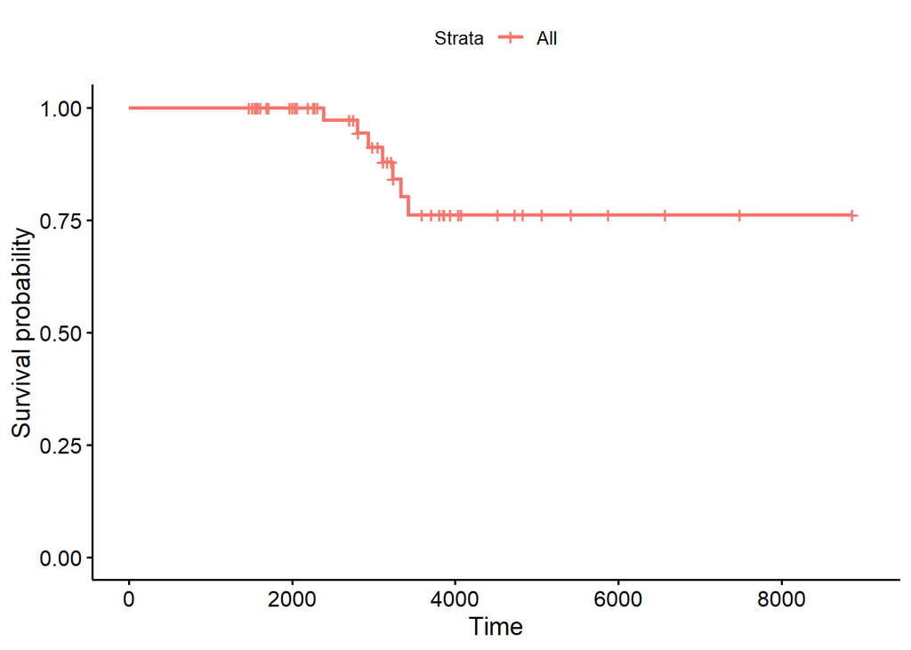

```r
ggsurvplot(survfit(op_cox),data =coxdata,conf.int = FALSE)
```

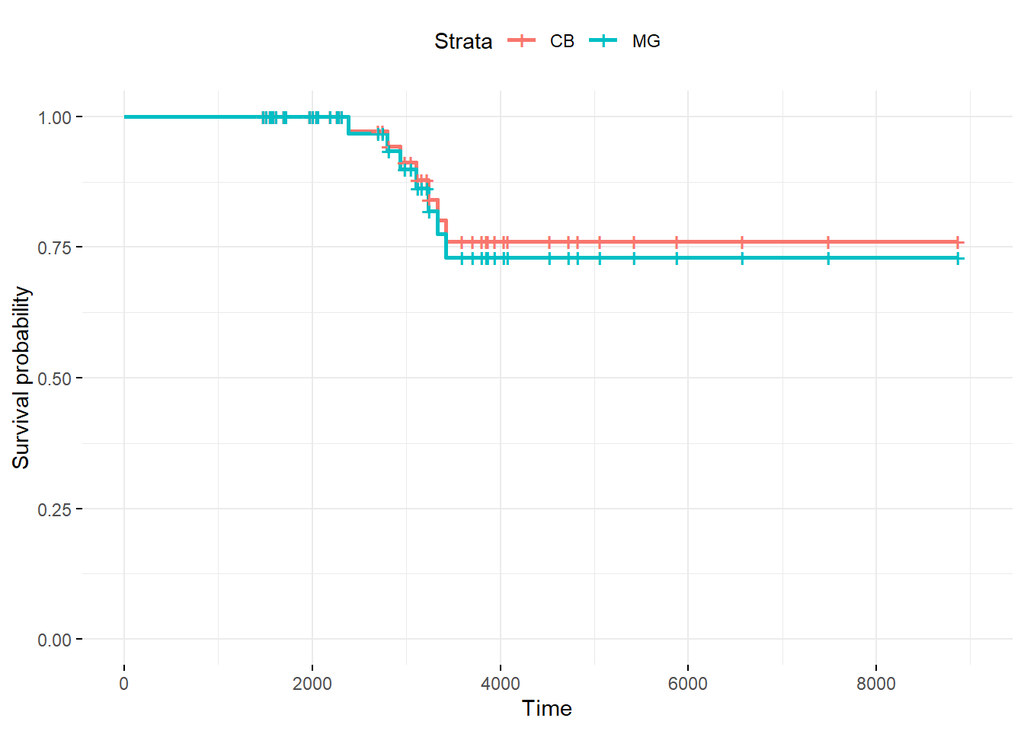

```r
new_df=data.frame("operator"=c("CB","MG"),"freeThawCycle"=c("0"),"total.protein.concentration"=mean(coxdata$total.protein.concentration),"batch"="3")
fit=survfit(op_cox,newdata = new_df)
op_survplot=ggsurvplot(fit, legend.labs=c("CB","MG"),data = coxdata,ggtheme = theme_minimal(),conf.int = FALSE,pval = TRUE)
op_survplot
```

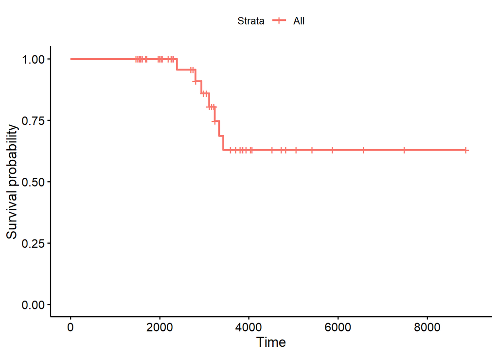

```r
ggsurvplot(survfit(thaw_cox),data =coxdata,conf.int = FALSE)
```

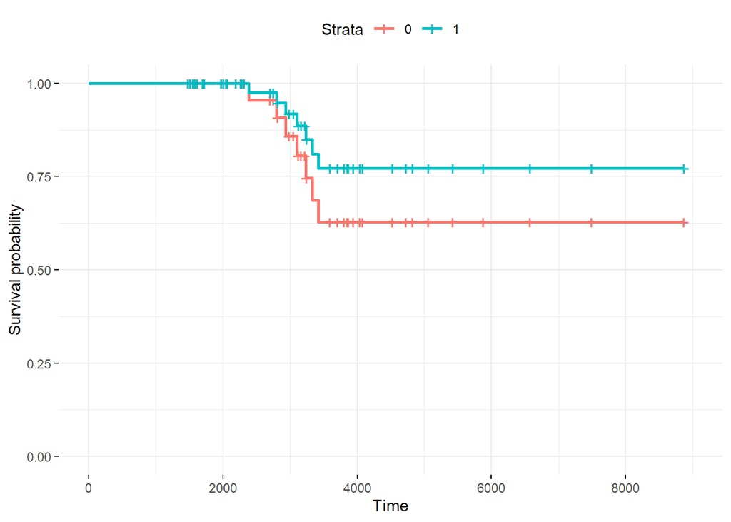

```r
new_df=data.frame("operator"=c("CB"),"freeThawCycle"=c("0","1"),"total.protein.concentration"=mean(coxdata$total.protein.concentration),"batch"="3")
fit=survfit(thaw_cox,newdata = new_df)
thaw_survplot=ggsurvplot(fit, legend.labs=c("0","1"),data = coxdata,ggtheme = theme_minimal(),conf.int = FALSE,pval = TRUE)
thaw_survplot
```

#### conclusion: technical factor are not having effect on survival modelling

### PCA analysis to assess if the technical factors are having an impact on the abundances

Here, we try to see if the technical factors confound the protein values to an extent that we can observe data separating based on these technical factors into different clusters.

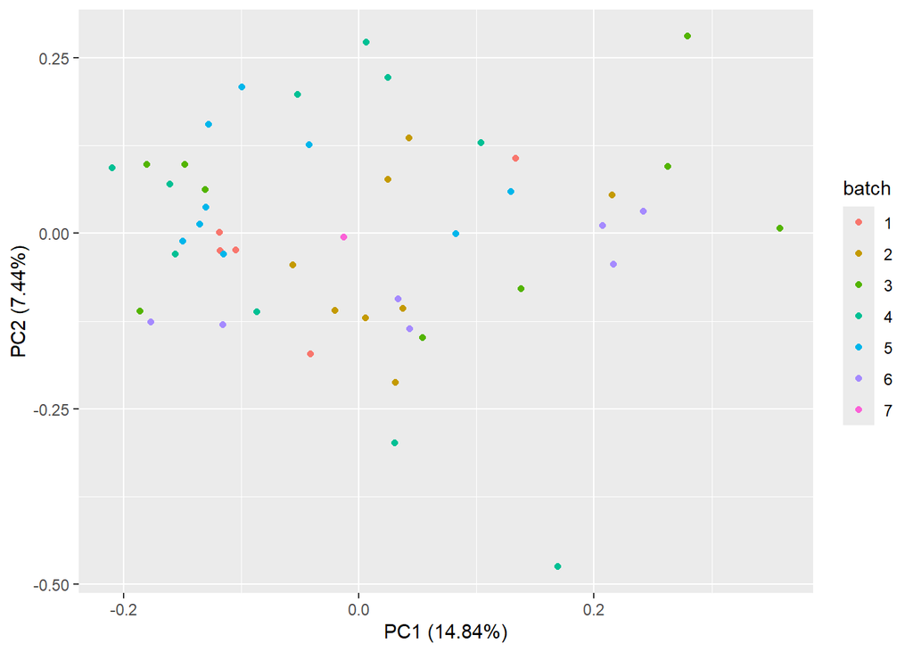

```r
t_imp=t(imputed)
pca_imp=prcomp(t_imp,scale. = T,center = T)

autoplot(pca_imp, data=coxdata,colour='batch')
```

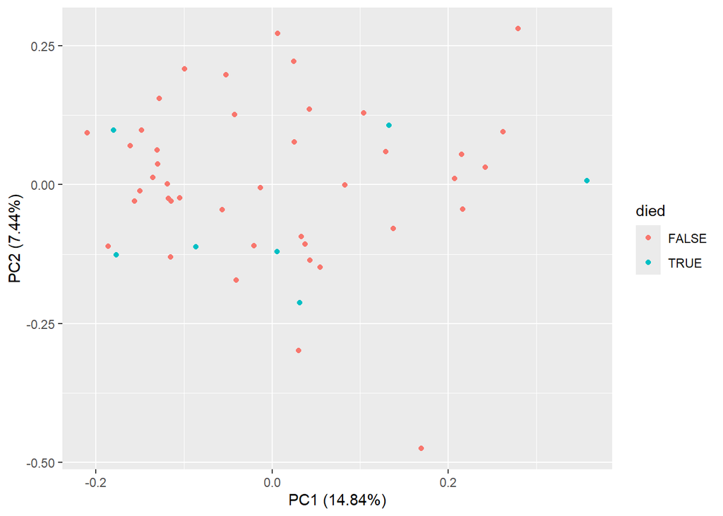

```r
autoplot(pca_imp, data=coxdata,colour='died')
```

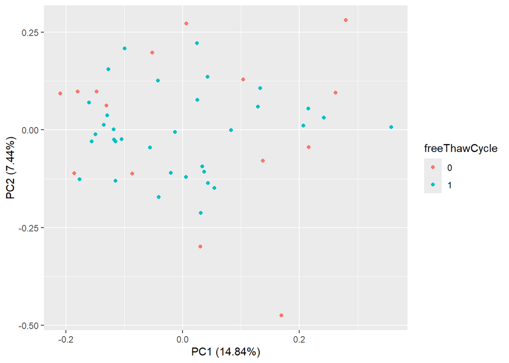

```r
autoplot(pca_imp, data=coxdata,colour='freeThawCycle')
```

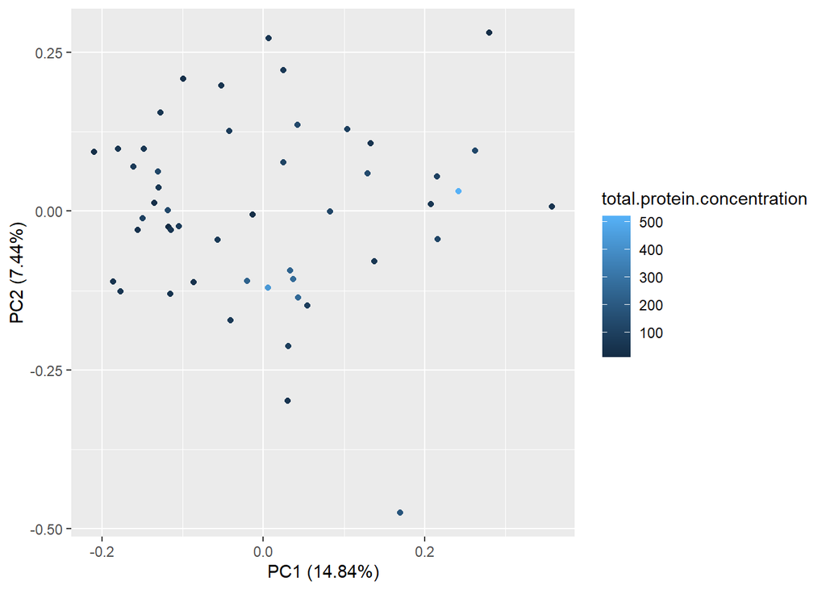

```r
autoplot(pca_imp, data=coxdata,colour='total.protein.concentration')
```

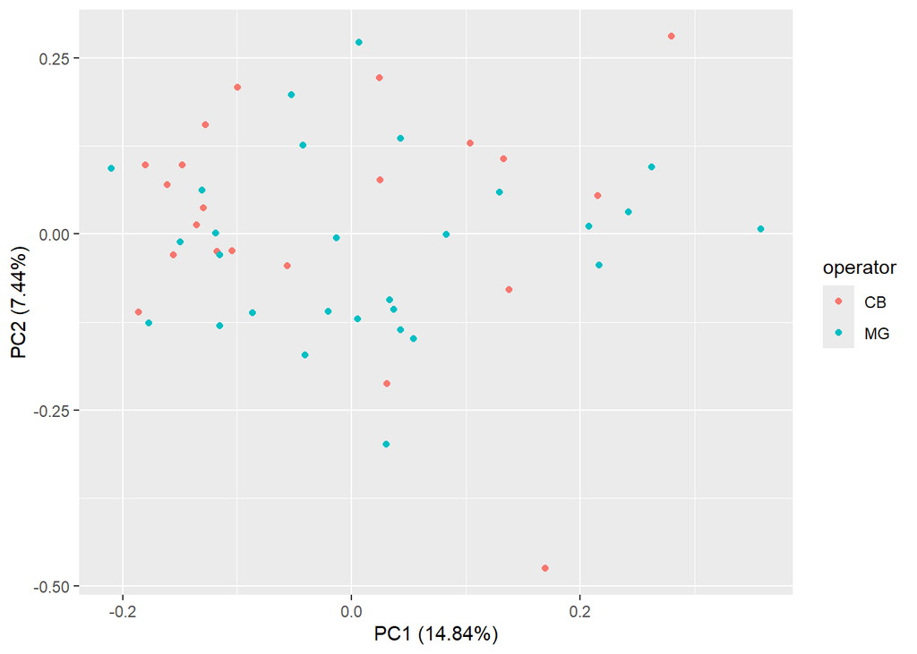

```r
autoplot(pca_imp, data=coxdata,colour='operator')
```

#### conclusion from the PCA plots: No obvious cluster separation observed in samples based on technical factors

## Protein Markers for Prognosis

```r
#Removing the technical factor columns. Cleaning up to just keep event, time and abundances.

colnames(coxdata)[dim(imputed)[1]:dim(coxdata)[2]]
```

```
##  [1] "sp|Q8NHQ9|DDX55_HUMAN"       "operator"
##  [3] "batch"                       "total.protein.concentration"
##  [5] "freeThawCycle"               "date.of.diagnosis"
##  [7] "died"                        "last.known.alive"
##  [9] "time"                        "event"
```

```r
protein_coxdata=coxdata[,! colnames(coxdata) %in% c("batch","operator","total.protein.concentration","conc","died","last.known.alive","date.of.diagnosis","freeThawCycle")]


#had to apply make.names to features because next line was throwing errors with default name due to some character encoding
colnames(protein_coxdata)=make.names(colnames(protein_coxdata))


#following function would do cox regression for each protein feature in a parallelized manner

prognosis <- RegParallel(
  data = protein_coxdata,
  formula = 'Surv(time, event) ~ [*]',
  FUN = function(formula, data)
    coxph(formula = formula,
          data = data,
          ties = 'breslow',
          singular.ok = TRUE),
  FUNtype = 'coxph',
  variables = colnames(protein_coxdata)[1:(ncol(protein_coxdata)-2)],
  blocksize = 200,
  cores = 3,
  nestedParallel = FALSE,
  conflevel = 95)
```

```
##
## ##############################
## #RegParallel
## ##############################
```

```
## System is:
```

```
## -- Windows
```

```
## Blocksize:
```

```
## -- 200
```

```
## Cores / Threads:
```

```
## -- 3
```

```
## Terms included in model:
```

```
## -- time
```

```
## -- event
```

```
## First 5 formulae:
```

```
## -- Surv(time, event) ~ sp.A0A0B4J2F0.PIOS1_HUMAN
```

```
## -- Surv(time, event) ~ sp.A0A0U1RRE5.NBDY_HUMAN
```

```
## -- Surv(time, event) ~ sp.A0A0U1RRL7.MMPOS_HUMAN
```

```
## -- Surv(time, event) ~ sp.A0AV96.RBM47_HUMAN
```

```
## -- Surv(time, event) ~ sp.A0AVT1.UBA6_HUMAN
```

[output not shown]

[output not shown]

[output not shown]

[output not shown]

[output not shown]

[output not shown]

[output not shown]

[output not shown]

[output not shown]

[output not shown]

[output not shown]

[output not shown]

[output not shown]

[output not shown]

[output not shown]

[output not shown]

[output not shown]

[output not shown]

[output not shown]

[output not shown]

[output not shown]

[output not shown]

[output not shown]

[output not shown]

[output not shown]

[output not shown]

[output not shown]

[output not shown]

[output not shown]

[output not shown]

[output not shown]

[output not shown]

[output not shown]

[output not shown]

[output not shown]

[output not shown]

[output not shown]

[output not shown]

[output not shown]

[output not shown]

```
## Done!
```

```r
prognosis2=prognosis[!is.na(prognosis$P),]
prognosis2
```

```
##                        Variable                      Term         Beta
##    1: sp.A0A0B4J2F0.PIOS1_HUMAN sp.A0A0B4J2F0.PIOS1_HUMAN  0.083266934
##    2:  sp.A0A0U1RRE5.NBDY_HUMAN  sp.A0A0U1RRE5.NBDY_HUMAN -0.956823326
##    3: sp.A0A0U1RRL7.MMPOS_HUMAN sp.A0A0U1RRL7.MMPOS_HUMAN -0.211618707
##    4:     sp.A0AV96.RBM47_HUMAN     sp.A0AV96.RBM47_HUMAN  1.460487547
##    5:      sp.A0AVT1.UBA6_HUMAN      sp.A0AVT1.UBA6_HUMAN -0.713258306
##   ---
## 3871:     sp.Q8NHL6.LIRB1_HUMAN     sp.Q8NHL6.LIRB1_HUMAN -0.379422951
## 3872:     sp.Q8NHM5.KDM2B_HUMAN     sp.Q8NHM5.KDM2B_HUMAN -0.243489758
## 3873:     sp.Q8NHP6.MSPD2_HUMAN     sp.Q8NHP6.MSPD2_HUMAN  0.001217381
## 3874:     sp.Q8NHP8.PLBL2_HUMAN     sp.Q8NHP8.PLBL2_HUMAN -0.526090658
## 3875:     sp.Q8NHQ9.DDX55_HUMAN     sp.Q8NHQ9.DDX55_HUMAN  0.006790864
##       StandardError            Z           P        LRT        Wald    LogRank
##    1:     0.4730654  0.176015690 0.860281616 0.86101391 0.860281616 0.86026462
##    2:     1.0515811 -0.909890201 0.362880418 0.37430346 0.362880418 0.35873980
```

[output cut: 21 more lines]

```r
prognosis2 <- prognosis2[order(prognosis2$LogRank, decreasing = FALSE),]
signif_feature <- subset(prognosis2, LogRank < 0.01)
signif_feature2 <- subset(prognosis2, LogRank < 0.05)

kable(signif_feature2)
```

| Variable | Term | Beta | StandardError | Z | P | LRT | Wald | LogRank | HR | HRlower | HRupper |
| --- | --- | --- | --- | --- | --- | --- | --- | --- | --- | --- | --- |
| sp.P62304.RUXE_HUMAN | sp.P62304.RUXE_HUMAN | -0.8786037 | 0.4260962 | -2.061984 | 0.0392092 | 0.0080518 | 0.0392092 | 0.0000412 | 0.4153625 | 0.1801912 | 9.574608e-01 |
| sp.P11498.PYC_HUMAN | sp.P11498.PYC_HUMAN | -6.1132840 | 1.8727458 | -3.264343 | 0.0010972 | 0.0005073 | 0.0010972 | 0.0000734 | 0.0022133 | 0.0000564 | 8.691980e-02 |
| sp.O60341.KDM1A_HUMAN | sp.O60341.KDM1A_HUMAN | 4.7804905 | 1.9753683 | 2.420050 | 0.0155184 | 0.0034895 | 0.0155184 | 0.0001587 | 119.1627846 | 2.4814417 | 5.722387e+03 |
| sp.O95219.SNX4_HUMAN | sp.O95219.SNX4_HUMAN | 1.0313989 | 0.4097032 | 2.517429 | 0.0118215 | 0.0174225 | 0.0118215 | 0.0001949 | 2.8049869 | 1.2565820 | 6.261391e+00 |
| sp.Q07960.RHG01_HUMAN | sp.Q07960.RHG01_HUMAN | -1.2930804 | 0.5409206 | -2.390518 | 0.0168246 | 0.0038764 | 0.0168246 | 0.0002310 | 0.2744242 | 0.0950583 | 7.922364e-01 |
| sp.P55010.IF5_HUMAN | sp.P55010.IF5_HUMAN | 2.3726016 | 0.7389074 | 3.210959 | 0.0013229 | 0.0022019 | 0.0013229 | 0.0002660 | 10.7252584 | 2.5202793 | 4.564223e+01 |
| sp.P09525.ANXA4_HUMAN | sp.P09525.ANXA4_HUMAN | -0.8825449 | 0.3073155 | -2.871787 | 0.0040816 | 0.0150297 | 0.0040816 | 0.0003382 | 0.4137287 | 0.2265313 | 7.556194e-01 |
| sp.P60981.DEST_HUMAN | sp.P60981.DEST_HUMAN | -2.6300098 | 0.8478201 | -3.102085 | 0.0019216 | 0.0041872 | 0.0019216 | 0.0004555 | 0.0720778 | 0.0136816 | 3.797231e-01 |
| sp.Q16644.MAPK3_HUMAN | sp.Q16644.MAPK3_HUMAN | 0.6003811 | 0.2150023 | 2.792441 | 0.0052312 | 0.0110068 | 0.0052312 | 0.0008762 | 1.8228134 | 1.1960021 | 2.778129e+00 |
| sp.P15884.ITF2_HUMAN | sp.P15884.ITF2_HUMAN | 3.0637919 | 1.0295207 | 2.975940 | 0.0029209 | 0.0023545 | 0.0029209 | 0.0009124 | 21.4085818 | 2.8461534 | 1.610340e+02 |
| sp.P41226.UBA7_HUMAN | sp.P41226.UBA7_HUMAN | 3.9732823 | 1.4179622 | 2.802107 | 0.0050770 | 0.0015376 | 0.0050770 | 0.0016136 | 53.1587278 | 3.3006766 | 8.561427e+02 |
| sp.O15321.TM9S1_HUMAN | sp.O15321.TM9S1_HUMAN | 2.8392191 | 1.0090334 | 2.813801 | 0.0048960 | 0.0049294 | 0.0048960 | 0.0016514 | 17.1024042 | 2.3668260 | 1.235799e+02 |
| sp.O15446.RPA34_HUMAN | sp.O15446.RPA34_HUMAN | 0.4434901 | 0.1847996 | 2.399844 | 0.0164021 | 0.0416815 | 0.0164021 | 0.0017420 | 1.5581358 | 1.0846850 | 2.238242e+00 |
| sp.Q6ZMZ3.SYNE3_HUMAN | sp.Q6ZMZ3.SYNE3_HUMAN | -2.8739599 | 1.0473824 | -2.743945 | 0.0060706 | 0.0053293 | 0.0060706 | 0.0019631 | 0.0564748 | 0.0072497 | 4.399350e-01 |
| sp.A6NHR9.SMHD1_HUMAN | sp.A6NHR9.SMHD1_HUMAN | -1.4794391 | 0.5396051 | -2.741707 | 0.0061121 | 0.0113132 | 0.0061121 | 0.0022573 | 0.2277654 | 0.0790997 | 6.558439e-01 |
| sp.P32248.CCR7_HUMAN | sp.P32248.CCR7_HUMAN | 0.4441527 | 0.1740228 | 2.552268 | 0.0107024 | 0.0278617 | 0.0107024 | 0.0022759 | 1.5591686 | 1.1085739 | 2.192914e+00 |
| sp.Q15631.TSN_HUMAN | sp.Q15631.TSN_HUMAN | -1.4478798 | 0.5299881 | -2.731910 | 0.0062968 | 0.0165370 | 0.0062968 | 0.0023558 | 0.2350682 | 0.0831892 | 6.642330e-01 |
| sp.Q06265.EXOS9_HUMAN | sp.Q06265.EXOS9_HUMAN | 1.6230505 | 0.5769849 | 2.812986 | 0.0049084 | 0.0056930 | 0.0049084 | 0.0024242 | 5.0685284 | 1.6358801 | 1.570407e+01 |
| sp.O95671.ASML_HUMAN | sp.O95671.ASML_HUMAN | -1.2720397 | 0.4562070 | -2.788295 | 0.0052986 | 0.0115431 | 0.0052986 | 0.0025929 | 0.2802594 | 0.1146136 | 6.853055e-01 |
| sp.P51808.DYLT3_HUMAN | sp.P51808.DYLT3_HUMAN | -1.3456628 | 0.5193900 | -2.590852 | 0.0095739 | 0.0127077 | 0.0095739 | 0.0026017 | 0.2603671 | 0.0940764 | 7.205957e-01 |
| sp.O00221.IKBE_HUMAN | sp.O00221.IKBE_HUMAN | -7.7140438 | 2.8284560 | -2.727298 | 0.0063855 | 0.0029456 | 0.0063855 | 0.0028863 | 0.0004465 | 0.0000017 | 1.141352e-01 |
| sp.Q7Z3V4.UBE3B_HUMAN | sp.Q7Z3V4.UBE3B_HUMAN | 0.4880711 | 0.2025366 | 2.409791 | 0.0159616 | 0.0465385 | 0.0159616 | 0.0030563 | 1.6291706 | 1.0953857 | 2.423071e+00 |
| sp.O75312.ZPR1_HUMAN | sp.O75312.ZPR1_HUMAN | 0.8098497 | 0.3862737 | 2.096570 | 0.0360317 | 0.0677755 | 0.0360317 | 0.0034168 | 2.2475702 | 1.0541841 | 4.791925e+00 |
| sp.P82650.RT22_HUMAN | sp.P82650.RT22_HUMAN | -1.2690220 | 0.4194692 | -3.025305 | 0.0024838 | 0.0017169 | 0.0024838 | 0.0034209 | 0.2811064 | 0.1235429 | 6.396222e-01 |
| sp.Q14457.BECN1_HUMAN | sp.Q14457.BECN1_HUMAN | -1.6006411 | 0.6060523 | -2.641094 | 0.0082639 | 0.0045904 | 0.0082639 | 0.0035136 | 0.2017671 | 0.0615145 | 6.617943e-01 |
| sp.Q14202.ZMYM3_HUMAN | sp.Q14202.ZMYM3_HUMAN | -1.9470371 | 0.7095030 | -2.744227 | 0.0060654 | 0.0109854 | 0.0060654 | 0.0037109 | 0.1426962 | 0.0355208 | 5.732481e-01 |
| sp.Q6VMQ6.MCAF1_HUMAN | sp.Q6VMQ6.MCAF1_HUMAN | 5.6920782 | 2.0542850 | 2.770832 | 0.0055913 | 0.0023726 | 0.0055913 | 0.0037996 | 296.5091831 | 5.2896580 | 1.662068e+04 |
| sp.P06753.TPM3_HUMAN | sp.P06753.TPM3_HUMAN | -2.0788485 | 0.7582302 | -2.741712 | 0.0061120 | 0.0093307 | 0.0061120 | 0.0040267 | 0.1250742 | 0.0282983 | 5.528080e-01 |
| sp.Q7Z2E3.APTX_HUMAN | sp.Q7Z2E3.APTX_HUMAN | 1.2294389 | 0.4532901 | 2.712256 | 0.0066827 | 0.0110451 | 0.0066827 | 0.0041209 | 3.4193104 | 1.4063626 | 8.313420e+00 |
| sp.Q14289.FAK2_HUMAN | sp.Q14289.FAK2_HUMAN | 0.7223728 | 0.2901345 | 2.489786 | 0.0127820 | 0.0266883 | 0.0127820 | 0.0044063 | 2.0593138 | 1.1661640 | 3.636515e+00 |

[output cut: 215 more lines]

```r
prognostic_proteins <- str_split_fixed(signif_feature2$Variable,pattern = "\\.",3)[,2]

prognostic_gene     <- str_remove(str_split_fixed(signif_feature2$Variable,pattern = "\\.",3)[,3],"_HUMAN")

print(prognostic_gene)
```

```
##   [1] "RUXE"  "PYC"   "KDM1A" "SNX4"  "RHG01" "IF5"   "ANXA4" "DEST"  "MAPK3"
##  [10] "ITF2"  "UBA7"  "TM9S1" "RPA34" "SYNE3" "SMHD1" "CCR7"  "TSN"   "EXOS9"
##  [19] "ASML"  "DYLT3" "IKBE"  "UBE3B" "ZPR1"  "RT22"  "BECN1" "ZMYM3" "MCAF1"
##  [28] "TPM3"  "APTX"  "FAK2"  "UTRO"  "LRC57" "BRPF1" "IVD"   "NKTR"  "VATA"
##  [37] "S10AB" "SRP19" "RN220" "RUNX1" "KMT2A" "SUMF1" "RT10"  "BAG4"  "RHG12"
##  [46] "PMGE"  "JADE1" "DNM1L" "DRS7B" "MAP7"  "SPT5H" "GPBP1" "IF2B3" "TNG2"
##  [55] "DPYD"  "3HAO"  "CD72"  "ACSL1" "PSMD3" "NUDT3" "IDHC"  "RPP30" "RPA1"
##  [64] "APT"   "BASI"  "EIF1"  "SNX16" "ZBED1" "PEBB"  "SUMF2" "IRF2"  "FBRL"
##  [73] "RBM47" "HEM4"  "BAP18" "TYB4"  "BZW1"  "UMPS"  "LRC47" "AF10"  "CUL4B"
##  [82] "CCD58" "ALG11" "ATLA2" "RS27A" "PUR8"  "YS060" "RHG17" "CCYL1" "MLH1"
##  [91] "GSH0"  "GLRX1" "CC038" "FUCO"  "CLPX"  "ROA1"  "CBL"   "TDIF2" "MPZL1"
## [100] "AKA12" "IGHG1" "ZN276" "NUMA1" "HMGB3" "TAF6"  "U119B" "IF4H"  "ANAG"
## [109] "DP13B" "RL22L" "DC1L2" "KRT85" "T2FB"  "RRAGA" "RN169" "CPSF4" "HMBX1"
## [118] "AT2C1" "OGT1"  "BAX"   "JAK1"  "NCKPL" "ZN638" "PGK1"  "AGAL"  "RS3A"
## [127] "PGRC2" "OAS2"  "R3HD1" "ARI5B" "PK3CD" "RS23"  "TRI65" "DHX30" "ATX1"
## [136] "ERF3A" "ITPK1" "CUL2"  "PPP6"  "ISCA2" "TRM2A" "MDC1"  "NIPA1" "H90B4"
## [145] "LYRM7" "ABCD1" "AK1A1" "ARF6"  "RS15"  "ICMT"  "CL17A" "EXOC3" "SC61G"
## [154] "VATB2" "NDUF5" "AP5B1" "UBR4"  "NT5D1" "FMNL1" "RL7A"  "CAPR1" "RS10"
## [163] "GDPD1" "I2BP1" "PARP1" "ARC1B" "TUT4"  "PIPNB" "LETM1" "DDI2"  "STIM1"
## [172] "CY24A" "ZCH18" "G6PI"  "CE350" "MCE1"  "U520"  "SF3A3" "ZN609" "BCOR"
## [181] "ABCF1" "UTP20" "TXN4A" "MYSM1" "HEAT6" "CARM1" "MPI"   "DYLT1" "PAX9"
## [190] "PHAR2" "BRE1A" "STT3A" "MINK1" "RNAS2" "HLAE"  "HMCS1" "SPAG7" "LRMP"
## [199] "ZMYM4" "CKAP4" "HLAF"  "NR2C2" "AAKG1" "BPI"   "TMC6"  "PDIA4" "COPE"
## [208] "TBCD1" "PEX14" "EIF3G" "MTMR5" "KNTC1" "RFX5"  "OXSR1" "CPSF7" "ZN770"
## [217] "G6PD"  "ARP2"  "FAHD1" "KDEL2" "H2AY"  "VASP"  "CAZA1" "LMNB2" "GSTCD"
## [226] "DJC13" "FCRLA" "MP2K6" "RSBN1" "RAB30" "CPZIP" "SEC20" "RRP5"  "MCTP2"
## [235] "BACH1" "MET15" "NB5R2" "JAGN1" "KAD2"  "SNW1"  "TPC10" "NGDN"  "NDUF7"
## [244] "UAP1"  "ARHGI"
```

### Example survival plot with one of the significant proteins

```r
survplotdata=protein_coxdata[,c("time","event",signif_feature2$Variable[1])]

colnames(survplotdata) <- c('time', 'event','RUXE')
range(survplotdata$RUXE)
```

```
## [1]  9.83678 17.15629
```

```r
median(survplotdata$RUXE)
```

```
## [1] 16.33001
```

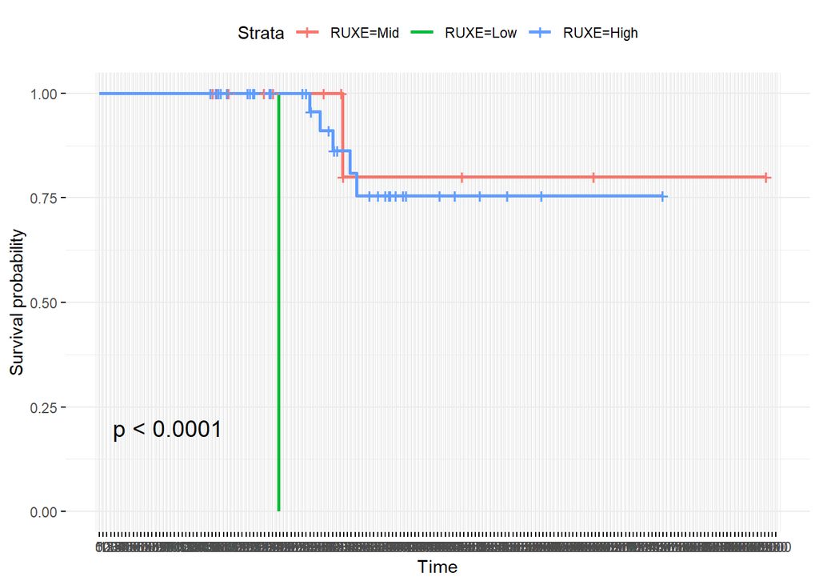

```r
highExpr <- 16
lowExpr <- 13
survplotdata$RUXE <- ifelse(survplotdata$RUXE >= highExpr, 'High',
                              ifelse(survplotdata$RUXE <= lowExpr, 'Low', 'Mid'))

survplotdata$RUXE <- factor(survplotdata$RUXE,levels = c('Mid', 'Low', 'High'))

ggsurvplot(survfit(Surv(time, event) ~ RUXE,
                   data = survplotdata),
           data = survplotdata,
           risk.table = F,
           pval = TRUE,
           break.time.by = 50,
           ggtheme = theme_minimal())
```

Here we can see that having low expression of RUXE have significant poor prognosis.

## Pathway Enrichment

### Using ReactomePA

ReactomePA package requires input genelist in Entrez ID.

```r
hs <- org.Hs.eg.db
my.symbols <- c(prognostic_gene)
entrez_map=select(hs,
                  keys = my.symbols,
                  columns = c("ENTREZID", "SYMBOL"),
                  keytype = "SYMBOL")
prognostic_gene_entrez=entrez_map[!is.na(entrez_map$ENTREZID),2]

x <- enrichPathway(gene=prognostic_gene_entrez,
                   pvalueCutoff=0.2,
                   qvalueCutoff=0.2,
                   readable=T)

reactome_pa_res=x@result

kable(reactome_pa_res[1:15,c(2,5,6,8)])
```

|  | Description | pvalue | p.adjust | geneID |
| --- | --- | --- | --- | --- |
| R-HSA-3700989 | Transcriptional Regulation by TP53 | 0.0015228 | 0.2143235 | BRPF1/RPA1/MLH1/TAF6/RRAGA/BAX/MDC1/CARM1/G6PD |
| R-HSA-110056 | MAPK3 (ERK1) activation | 0.0023755 | 0.2143235 | MAPK3/JAK1 |
| R-HSA-1855167 | Synthesis of pyrophosphates in the cytosol | 0.0023755 | 0.2143235 | NUDT3/ITPK1 |
| R-HSA-1059683 | Interleukin-6 signaling | 0.0028894 | 0.2143235 | CBL/JAK1 |
| R-HSA-1169410 | Antiviral mechanism by IFN-stimulated genes | 0.0029491 | 0.2143235 | MAPK3/UBA7/JAK1/OAS2 |
| R-HSA-5696400 | Dual Incision in GG-NER | 0.0034684 | 0.2143235 | RPA1/CUL4B/PARP1 |
| R-HSA-163841 | Gamma carboxylation, hypusine formation and arylsulfatase activation | 0.0037153 | 0.2143235 | SUMF1/SUMF2/ICMT |
| R-HSA-5696395 | Formation of Incision Complex in GG-NER | 0.0039727 | 0.2143235 | RPA1/CUL4B/PARP1 |
| R-HSA-1663150 | The activation of arylsulfatases | 0.0040583 | 0.2143235 | SUMF1/SUMF2 |
| R-HSA-2046104 | alpha-linolenic (omega3) and linoleic (omega6) acid metabolism | 0.0040583 | 0.2143235 | ACSL1/ABCD1 |
| R-HSA-2046106 | alpha-linolenic acid (ALA) metabolism | 0.0040583 | 0.2143235 | ACSL1/ABCD1 |
| R-HSA-5358565 | Mismatch repair (MMR) directed by MSH2:MSH6 (MutSalpha) | 0.0047118 | 0.2143235 | RPA1/MLH1 |
| R-HSA-5358606 | Mismatch repair (MMR) directed by MSH2:MSH3 (MutSbeta) | 0.0047118 | 0.2143235 | RPA1/MLH1 |
| R-HSA-5358508 | Mismatch Repair | 0.0054105 | 0.2143235 | RPA1/MLH1 |
| R-HSA-73893 | DNA Damage Bypass | 0.0054213 | 0.2143235 | UBA7/RPA1/CUL4B |

### Using pathfindR

```r
pfr_input=signif_feature2[,c(1,3,9)]
pfr_input$Variable=str_remove(str_split_fixed(pfr_input$Variable,pattern = "\\.",3)[,3],"_HUMAN")
colnames(pfr_input)=c("Gene.symbol","logFC","adj.P.Val")

pfr_out <- run_pathfindR(pfr_input)
```

```
## ## Testing input
```

```
## The input looks OK
```

```
## ## Processing input. Converting gene symbols,
##           if necessary (and if human gene symbols provided)
```

```
## Number of genes provided in input: 245
```

```
## Number of genes in input after p-value filtering: 245
```

```
## Could not find any interactions for 109 (44.49%) genes in the PIN
```

```
## Final number of genes in input: 136
```

```
## ## Performing Active Subnetwork Search and Enrichment
```

```
## `n_processes` is set to `iterations` because `iterations` < `n_processes`
```

```
## ## Processing the enrichment results over all iterations
```

```
## ## Annotating involved genes and visualizing enriched terms
```

```
## Plotting the enrichment bubble chart
```

```
## Found 67 enriched terms
```

```
## You may run:
```

```
## - cluster_enriched_terms() for clustering enriched terms
```

```
## - visualize_terms() for visualizing enriched term diagrams
```

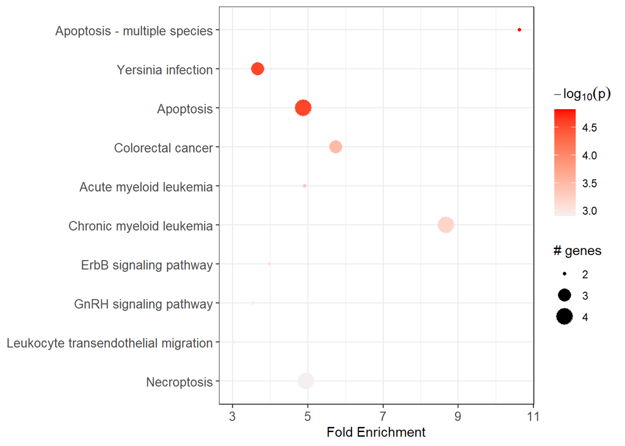

Pathways appearing are very relavant to Chronic lymphocytic leukemia (CLL)

## References:

Many many publications were considered for their algorithms and approach towards imputation and modelling, but following resources were of most help.

1. https://www.sciencedirect.com/science/article/pii/S1535947623000683#bib19
2. https://www.ncbi.nlm.nih.gov/pmc/articles/PMC6944043/
3. https://www.biostars.org/p/344233/
4. https://bioconductor.org/packages/release/data/experiment/vignettes/RegParallel/inst/doc/RegParallel.html
5. https://cran.r-project.org/web/packages/pathfindR/vignettes/intro_vignette.html
6. https://bmcbioinformatics.biomedcentral.com/articles/10.1186/s12859-023-05360-7
7. http://www.sthda.com/english/wiki/cox-proportional-hazards-model